# Drake_Zhou_Part_02_A

Drake Zhou

4/22/2022

# 1 Overview & Preparation

Before using advanced methods, you need to develop a baseline understanding of the log-transformed response as a function of the inputs using linear modeling techniques.

## 1.1 Package Import

```r
library(tidyverse)
library(caret)
library(coefplot)
library(splines)
library(yardstick)
```

## 1.2 Data Import

Before I fit into linear models, I want transform the response to log-response and standardized the inputs and outputs especially those continuous inputs and resampling.

```r
# Read CSV
df_all <- readr::read_csv("final_project_train.csv", col_names = TRUE)
# Standardize data
standard_df_all <- df_all %>%
  select(starts_with("x")) %>%
  scale(center = TRUE, scale = TRUE) %>%
  as.data.frame() %>%
  tibble::as_tibble() %>%
  mutate(y = log(df_all$response),
         region = factor(df_all$region, levels = c("XX", "YY", "ZZ")),
         customer = factor(df_all$customer, levels = c("A", "B", "D", "E", "G", "Other", "Q", "M", "K")))

# Resampling validation
train_id <- sample(1:nrow(standard_df_all), size = floor(0.8 * nrow(standard_df_all)))
train_ready <- standard_df_all %>% slice(train_id)
test_ready <- standard_df_all %>% slice(-train_id)
```

# 2 Model Fitting

Use lm() to fit the following linear models: • Categorical variables only – linear additive • Continuous variables only – linear additive • All categorical and continuous variables – linear additive • Interact region with continuous inputs, do not include customer • Interact customer with continuous inputs, do not include region • All pairwise interactions of continuous inputs, do not include categorical inputs • 3 models with basis functions of your choice • Can include interactions of the basis functions with other basis functions and with the categorical inputs!

```r
# Model for categorical variables
mod1 = lm(y ~ region + customer, data = standard_df_all)

# Model for continuous variables only additively &
mod2 = lm(y ~ ., data = standard_df_all[c(-36, -35)])

# All categorical and continuous variables
mod3 <- lm(y ~ ., data = standard_df_all)

# Interact region with continuous inputs, do not include customer
mod4 <- lm(y ~ region * ., data = standard_df_all[-36])

# Interact customer with continuous inputs, do not include region
mod5 <- lm(y ~ customer * ., data = standard_df_all[-35])

# All pairwise interactions of continuous inputs
mod6 = lm(y ~ (.)^2, data = standard_df_all[c(-36, -35)])

# Model with polynomial
mod7 <- lm(y ~ poly(xb_01, 2)+poly(xb_02, 2)+ poly(xb_03,2)+poly(xn_01,2)+poly(xn_02,2)+poly(xn_03,2)+poly(xa_01,2)+poly(xa_02,2)+poly(xa_03,2)+poly(xb_04,2)+poly(xb_05,2)+poly(xb_06,2)+poly(xb_07,2)+poly(xb_08,2)+poly(xn_04,2)+poly(xn_05,2)+poly(xn_06,2)+poly(xn_07,2)+poly(xn_08,2)+poly(xa_04,2)+poly(xa_05,2)+poly(xa_06,2)+poly(xa_07,2)+poly(xa_08,2)+poly(xw_01,2)+poly(xw_02,2)+poly(xw_03,2)+poly(xs_01,2)+poly(xs_02,2)+poly(xs_03,2)+poly(xs_04,2)+poly(xs_05,2)+poly(xs_06,2)*region*customer, data = standard_df_all)

# Model with natural spline on continuous variables
mod8 <- lm(y ~ ns(xb_01, 2)+ns(xb_02, 2)+ ns(xb_03,2)+ns(xn_01,2)+ns(xn_02,2)+ns(xn_03,2)+ns(xa_01,2)+ns(xa_02,2)+ns(xa_03,2)+ns(xb_04,2)+ns(xb_05,2)+ns(xb_06,2)+ns(xb_07,2)+ns(xb_08,2)+ns(xn_04,2)+ns(xn_05,2)+ns(xn_06,2)+ns(xn_07,2)+ns(xn_08,2)+ns(xa_04,2)+ns(xa_05,2)+ns(xa_06,2)+ns(xa_07,2)+ns(xa_08,2)+ns(xw_01,2)+ns(xw_02,2)+ns(xw_03,2)+ns(xs_01,2)+ns(xs_02,2)+ns(xs_03,2)+ns(xs_04,2)+ns(xs_05,2)+ns(xs_06,2), data = standard_df_all)

# Model with natural spline with higher degree of freedom
mod9 <- lm(y ~ ns(xb_01, 3)+ns(xb_03, 3)+ ns(xb_03,3)+ns(xn_01,3)+ns(xn_03,3)+ns(xn_03,3)+ns(xa_01,3)+ns(xa_03,3)+ns(xa_03,3)+ns(xb_04,3)+ns(xb_05,3)+ns(xb_06,3)+ns(xb_07,3)+ns(xb_08,3)+ns(xn_04,3)+ns(xn_05,3)+ns(xn_06,3)+ns(xn_07,3)+ns(xn_08,3)+ns(xa_04,3)+ns(xa_05,3)+ns(xa_06,3)+ns(xa_07,3)+ns(xa_08,3)+ns(xw_01,3)+ns(xw_03,3)+ns(xw_03,3)+ns(xs_01,3)+ns(xs_03,3)+ns(xs_03,3)+ns(xs_04,3)+ns(xs_05,3)+ns(xs_06,3)+region+customer, data = standard_df_all)
```

# 3 Model Evaluation

## 3.1 Binding data together

```r
p1 <- broom::glance(mod1)
p2 <- broom::glance(mod2)
p3 <- broom::glance(mod3)
p4 <- broom::glance(mod4)
p5 <- broom::glance(mod5)
p6 <- broom::glance(mod6)
p7 <- broom::glance(mod7)
p8 <- broom::glance(mod8)
p9 <- broom::glance(mod9)

p_all <- rbind(p1,p2,p3,p4,p5,p6,p7,p8,p9) %>%
  tibble::rowid_to_column()
```

## 3.2 R-squared perspective

The closer r-squared value is close to one, the better the model is.

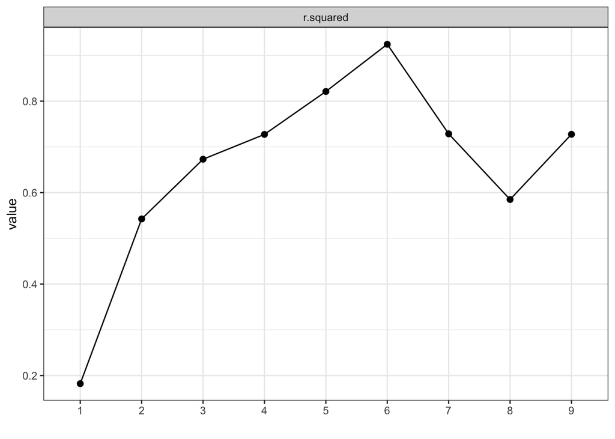

```r
p_all %>%
  select(r.squared, rowid) %>%
  pivot_longer(-c("rowid")) %>%
  mutate(model_id = stringr::str_extract(rowid, "\\d+")) %>%
  ggplot(mapping = aes(x = model_id, y = value, group = 1))+
  geom_path()+
  geom_point(size = 2.0)+
  facet_grid(~name, scales = "free")+
  labs(x = '')+
  theme_bw()
```

## 3.3 AIC & BIC

AIC and BIC are information criterion metrics, hence we want to minimize them which represent a better model.

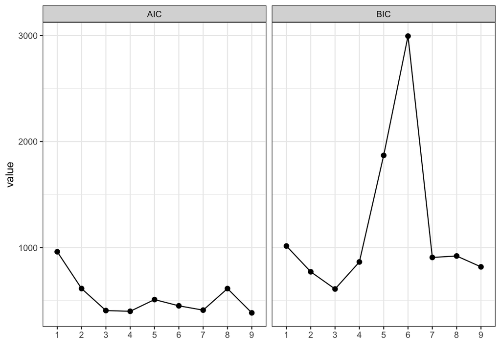

```r
p_all %>%
  select(AIC, BIC, rowid) %>%
  pivot_longer(-c("rowid")) %>%
  mutate(model_id = stringr::str_extract(rowid, "\\d+")) %>%
  ggplot(mapping = aes(x = model_id, y = value, group = 1))+
  geom_path()+
  geom_point(size = 2.0)+
  facet_grid(~name, scales = "free")+
  labs(x = '')+
  theme_bw()
```

## 3.4 Compare models

Which of the 9 models is the best? What performance metric did you use to make your selection?

[output not shown]

# 4 Train-test split

## 4.1 Train and assess models

```r
fit_and_assess <- function(a_formula, model_name, train_data, test_data, y_name)
{
  mod <- lm( a_formula, data = train_data)

  pred_train <- as.vector(mod$fitted.values)

  y_train <- train_data %>% dplyr::select(all_of(y_name)) %>% pull()

  train_metrics <- tibble::tibble(
    rmse_value = rmse_vec(y_train, pred_train),
    mae_value = mae_vec(y_train, pred_train),
    r2_value = rsq_vec(y_train, pred_train)
  )

  pred_test <- as.vector(predict(mod, newdata = test_data))

  y_test <- test_data %>% dplyr::select(all_of(y_name)) %>% pull()

  test_metrics <- tibble::tibble(
    rmse_value = rmse_vec(y_test, pred_test),
    mae_value = mae_vec(y_test, pred_test),
    r2_value = rsq_vec(y_test, pred_test)
  )

  train_metrics %>% mutate(on_set = "train") %>%
    bind_rows(test_metrics %>% mutate(on_set = "test")) %>%
    mutate(model_name = model_name)
}
```

```r
one_split_results <- purrr::map2_dfr(list(formula(mod1), formula(mod2), formula(mod3),
                                         formula(mod4), formula(mod5), formula(mod6),
                                         formula(mod7), formula(mod8), formula(mod9)),
                                     sprintf("mod%2d", 1:9),
                                     fit_and_assess,
                                     train_data = train_ready,
                                     test_data = test_ready,
                                     y_name = "y")
```

## 4.2 RMSE performance on Train and Test sets

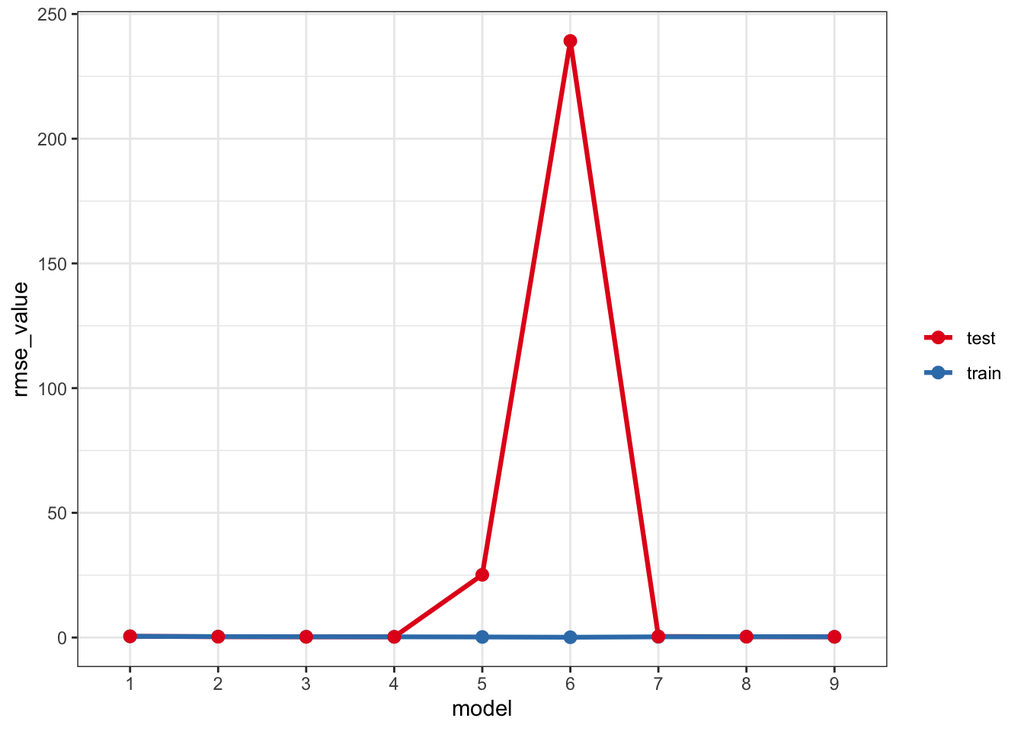

```r
one_split_results %>%
  mutate(model_id = stringr::str_extract(model_name, "\\d+")) %>%
  ggplot(mapping = aes(x = model_id, y = rmse_value)) +
  geom_line(mapping = aes(color = on_set,
                          group = on_set),
            size = 1.1) +
  geom_point(mapping = aes(color = on_set),
             size = 2.5) +
  scale_color_brewer("", palette = "Set1") +
  labs(x = 'model') +
  theme_bw()
```

## 4.3 R-Squared performance on Train and Test sets

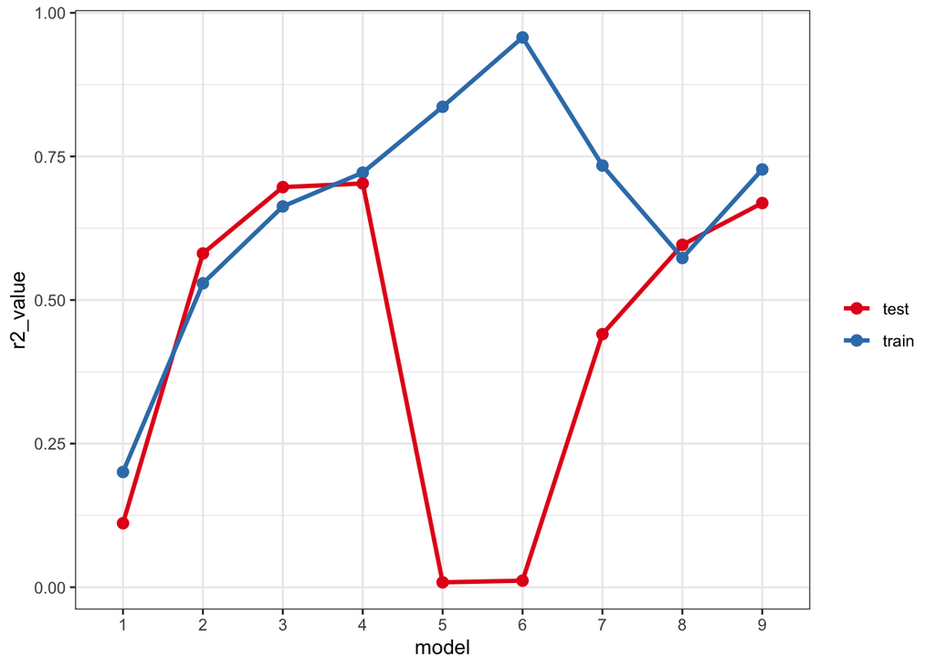

```r
one_split_results %>%
  mutate(model_id = stringr::str_extract(model_name, "\\d+")) %>%
  ggplot(mapping = aes(x = model_id, y = r2_value)) +
  geom_line(mapping = aes(color = on_set,
                          group = on_set),
            size = 1.1) +
  geom_point(mapping = aes(color = on_set),
             size = 2.5) +
  scale_color_brewer("", palette = "Set1") +
  labs(x = 'model') +
  theme_bw()
```

# 5 Conclusion

[output not shown]

# 6 Coefficient inspection

Visualize the coefficient summaries for your top 3 models. How do the coefficient summaries compare between the top 3?

## 6.1 Function

```r
sig_input_inspect <- function(mod){
  df <- mod %>%
        coefplot(sort = "magnitude", plot = FALSE) %>%
        tibble::as_tibble() %>%
        filter((HighOuter > 0 & LowOuter > 0) | (HighOuter < 0 & LowOuter < 0))
  return(df)
}
```

## 6.2 Model #9

```r
summary(mod9)
```

```
##
## Call:
## lm(formula = y ~ ns(xb_01, 3) + ns(xb_03, 3) + ns(xb_03, 3) +
##     ns(xn_01, 3) + ns(xn_03, 3) + ns(xn_03, 3) + ns(xa_01, 3) +
##     ns(xa_03, 3) + ns(xa_03, 3) + ns(xb_04, 3) + ns(xb_05, 3) +
##     ns(xb_06, 3) + ns(xb_07, 3) + ns(xb_08, 3) + ns(xn_04, 3) +
##     ns(xn_05, 3) + ns(xn_06, 3) + ns(xn_07, 3) + ns(xn_08, 3) +
##     ns(xa_04, 3) + ns(xa_05, 3) + ns(xa_06, 3) + ns(xa_07, 3) +
##     ns(xa_08, 3) + ns(xw_01, 3) + ns(xw_03, 3) + ns(xw_03, 3) +
##     ns(xs_01, 3) + ns(xs_03, 3) + ns(xs_03, 3) + ns(xs_04, 3) +
##     ns(xs_05, 3) + ns(xs_06, 3) + region + customer, data = standard_df_all)
##
## Residuals:
##     Min      1Q  Median      3Q     Max
## -1.1023 -0.1848  0.0029  0.1777  1.1727
##
## Coefficients:
##                Estimate Std. Error t value Pr(>|t|)
## (Intercept)    0.980335   0.448623   2.185  0.02927 *
## ns(xb_01, 3)1  1.106988   0.343306   3.224  0.00133 **
## ns(xb_01, 3)2  1.925159   1.055156   1.825  0.06859 .
## ns(xb_01, 3)3 -0.310655   0.950086  -0.327  0.74380
## ns(xb_03, 3)1 -0.414531   0.295296  -1.404  0.16092
## ns(xb_03, 3)2  1.115776   0.609331   1.831  0.06759 .
## ns(xb_03, 3)3  1.621900   0.850398   1.907  0.05698 .
## ns(xn_01, 3)1  0.373699   0.234412   1.594  0.11143
## ns(xn_01, 3)2  0.191001   0.529690   0.361  0.71854
## ns(xn_01, 3)3 -0.087533   0.629726  -0.139  0.88950
## ns(xn_03, 3)1 -0.232127   0.243183  -0.955  0.34021
## ns(xn_03, 3)2 -0.170288   0.422380  -0.403  0.68698
## ns(xn_03, 3)3 -0.115411   0.602275  -0.192  0.84810
## ns(xa_01, 3)1  0.216394   0.265549   0.815  0.41547
## ns(xa_01, 3)2  1.746982   0.796358   2.194  0.02865 *
## ns(xa_01, 3)3  2.765719   1.187839   2.328  0.02023 *
## ns(xa_03, 3)1  0.297175   0.298683   0.995  0.32017
## ns(xa_03, 3)2 -1.251289   0.696471  -1.797  0.07292 .
## ns(xa_03, 3)3 -2.490546   1.124220  -2.215  0.02712 *
## ns(xb_04, 3)1 -2.040990   0.717893  -2.843  0.00463 **
## ns(xb_04, 3)2 -5.241758   1.876642  -2.793  0.00539 **
## ns(xb_04, 3)3 -3.114589   1.030387  -3.023  0.00262 **
```

[output cut: 64 more lines]

```
## regionZZ      -0.230674   0.048024  -4.803 1.99e-06 ***
## customerB     -0.112275   0.080210  -1.400  0.16212
## customerD     -0.035316   0.086744  -0.407  0.68407
## customerE     -0.043470   0.086937  -0.500  0.61725
## customerG     -0.111943   0.054834  -2.041  0.04166 *
## customerOther -0.008684   0.062355  -0.139  0.88929
## customerQ     -0.156111   0.086891  -1.797  0.07291 .
## customerM     -0.181550   0.059874  -3.032  0.00254 **
## customerK      0.320652   0.070187   4.569 6.00e-06 ***
## ---
## Signif. codes:  0 '***' 0.001 '**' 0.01 '*' 0.05 '.' 0.1 ' ' 1
##
## Residual standard error: 0.3009 on 582 degrees of freedom
## Multiple R-squared:  0.7276, Adjusted R-squared:  0.6836
## F-statistic: 16.53 on 94 and 582 DF,  p-value: < 2.2e-16
```

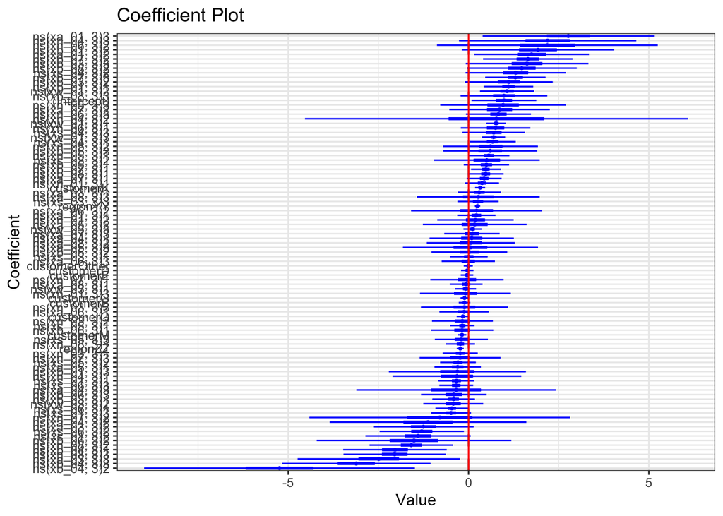

```r
mod9 %>%
  coefplot(scales = "free", sort = "magnitude", pointSize = 1, innerCI = 0.5)+
  geom_vline(xintercept = 0, color = "red")+
  theme_bw()+
  theme(legend.position = 'none')
```

```r
sig_input_inspect(mod9) %>% head()
```

```
## # A tibble: 6 × 7
##   Value Coefficient   HighInner LowInner HighOuter LowOuter Model
##   <dbl> <fct>             <dbl>    <dbl>     <dbl>    <dbl> <chr>
## 1 -5.24 ns(xb_04, 3)2     -3.37    -7.12    -1.49     -9.00 model
## 2 -3.11 ns(xb_04, 3)3     -2.08    -4.14    -1.05     -5.18 model
## 3 -2.49 ns(xa_03, 3)3     -1.37    -3.61    -0.242    -4.74 model
## 4 -2.05 ns(xn_08, 3)3     -1.34    -2.76    -0.631    -3.47 model
## 5 -2.04 ns(xb_04, 3)1     -1.32    -2.76    -0.605    -3.48 model
## 6 -1.59 ns(xn_08, 3)2     -1.01    -2.17    -0.432    -2.75 model
```

xb_04, xa_03, xn_08, xb_04 etc are important features

## 6.3 Model #3

```r
summary(mod3)
```

```
##
## Call:
## lm(formula = y ~ ., data = standard_df_all)
##
## Residuals:
##      Min       1Q   Median       3Q      Max
## -1.09325 -0.19510 -0.00288  0.19697  1.55830
##
## Coefficients:
##                Estimate Std. Error t value Pr(>|t|)
## (Intercept)    0.913119   0.064532  14.150  < 2e-16 ***
## xb_01          0.016545   0.069693   0.237 0.812420
## xb_02          0.072349   0.048441   1.494 0.135787
## xb_03          0.078891   0.065883   1.197 0.231583
## xn_01         -0.002322   0.057739  -0.040 0.967933
## xn_02          0.050453   0.045046   1.120 0.263121
## xn_03         -0.008634   0.049617  -0.174 0.861904
## xa_01         -0.073505   0.068226  -1.077 0.281722
## xa_02          0.102661   0.049490   2.074 0.038448 *
## xa_03         -0.001087   0.062455  -0.017 0.986122
## xb_04         -0.239963   0.077993  -3.077 0.002183 **
## xb_05          0.017585   0.056665   0.310 0.756410
## xb_06         -0.002727   0.039858  -0.068 0.945476
## xb_07          0.136213   0.037588   3.624 0.000314 ***
## xb_08          0.106700   0.043696   2.442 0.014884 *
## xn_04          0.152826   0.072685   2.103 0.035897 *
## xn_05          0.095475   0.046964   2.033 0.042475 *
## xn_06          0.031155   0.035962   0.866 0.386631
## xn_07         -0.006782   0.032114  -0.211 0.832824
## xn_08         -0.096149   0.039045  -2.463 0.014062 *
## xa_04          0.057343   0.077536   0.740 0.459834
## xa_05          0.028128   0.050331   0.559 0.576451
## xa_06         -0.033532   0.037452  -0.895 0.370952
## xa_07          0.033956   0.041716   0.814 0.415964
## xa_08         -0.027349   0.046561  -0.587 0.557162
## xw_01          0.271545   0.059376   4.573 5.78e-06 ***
## xw_02          0.007303   0.044499   0.164 0.869696
## xw_03         -0.080088   0.046458  -1.724 0.085217 .
## xs_01         -0.027786   0.034077  -0.815 0.415163
## xs_02         -0.043988   0.034263  -1.284 0.199666
## xs_03         -0.006927   0.032333  -0.214 0.830436
## xs_04         -0.014464   0.041031  -0.353 0.724572
## xs_05          0.017900   0.038959   0.459 0.646074
## xs_06          0.020593   0.034216   0.602 0.547496
## regionYY       0.277325   0.036827   7.530 1.75e-13 ***
## regionZZ      -0.223741   0.048294  -4.633 4.38e-06 ***
## customerB     -0.126823   0.079286  -1.600 0.110197
## customerD     -0.068078   0.086112  -0.791 0.429486
## customerE     -0.098783   0.087048  -1.135 0.256884
## customerG     -0.108334   0.054033  -2.005 0.045392 *
## customerOther -0.050523   0.062017  -0.815 0.415577
## customerQ     -0.230559   0.085991  -2.681 0.007527 **
## customerM     -0.196191   0.057729  -3.398 0.000720 ***
## customerK      0.225894   0.069450   3.253 0.001204 **
## ---
## Signif. codes:  0 '***' 0.001 '**' 0.01 '*' 0.05 '.' 0.1 ' ' 1
##
## Residual standard error: 0.3161 on 633 degrees of freedom
## Multiple R-squared:  0.673,  Adjusted R-squared:  0.6508
## F-statistic: 30.29 on 43 and 633 DF,  p-value: < 2.2e-16
```

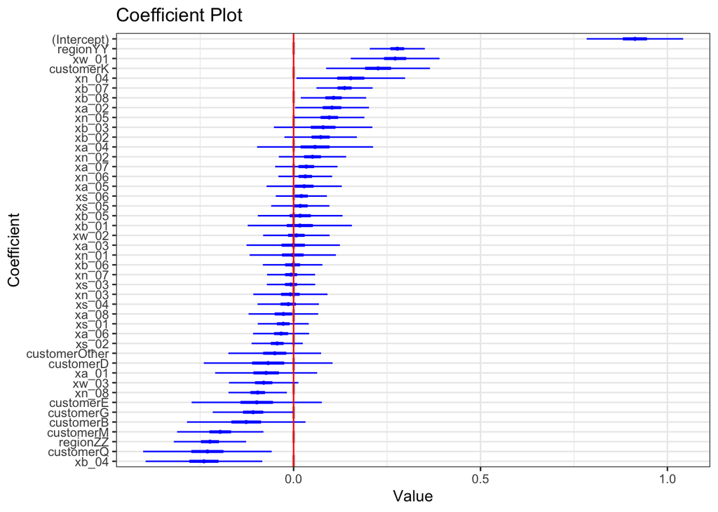

```r
mod3 %>%
  coefplot(scales = "free", sort = "magnitude", pointSize = 1, innerCI = 0.5)+
  geom_vline(xintercept = 0, color = "red")+
  theme_bw()+
  theme(legend.position = 'none')
```

```r
sig_input_inspect(mod3) %>% head()
```

```
## # A tibble: 6 × 7
##     Value Coefficient HighInner LowInner HighOuter LowOuter Model
##     <dbl> <fct>           <dbl>    <dbl>     <dbl>    <dbl> <chr>
## 1 -0.240  xb_04         -0.162    -0.318 -0.0840     -0.396 model
## 2 -0.231  customerQ     -0.145    -0.317 -0.0586     -0.403 model
## 3 -0.224  regionZZ      -0.175    -0.272 -0.127      -0.320 model
## 4 -0.196  customerM     -0.138    -0.254 -0.0807     -0.312 model
## 5 -0.108  customerG     -0.0543   -0.162 -0.000268   -0.216 model
## 6 -0.0961 xn_08         -0.0571   -0.135 -0.0181     -0.174 model
```

xb_04, customerQ, regionZZ etc. are important features

## 6.4 Model #4

```r
summary(mod4)
```

```
##
## Call:
## lm(formula = y ~ region * ., data = standard_df_all[-36])
##
## Residuals:
##      Min       1Q   Median       3Q      Max
## -1.14449 -0.17857 -0.01307  0.16378  1.60998
##
## Coefficients:
##                 Estimate Std. Error t value Pr(>|t|)
## (Intercept)     0.831570   0.028379  29.302  < 2e-16 ***
## regionYY        0.243185   0.038045   6.392 3.39e-10 ***
## regionZZ       -0.277151   0.044929  -6.169 1.30e-09 ***
## xb_01          -0.017088   0.145368  -0.118   0.9065
## xb_02           0.152569   0.077396   1.971   0.0492 *
## xb_03           0.076643   0.134999   0.568   0.5704
## xn_01          -0.051459   0.109206  -0.471   0.6377
## xn_02           0.013420   0.069173   0.194   0.8462
## xn_03           0.030606   0.092584   0.331   0.7411
## xa_01          -0.113436   0.143924  -0.788   0.4309
## xa_02           0.057401   0.085775   0.669   0.5036
## xa_03           0.109767   0.120630   0.910   0.3632
## xb_04          -0.335538   0.196361  -1.709   0.0880 .
## xb_05          -0.034126   0.098606  -0.346   0.7294
## xb_06          -0.014015   0.079828  -0.176   0.8607
## xb_07           0.198172   0.099659   1.989   0.0472 *
## xb_08           0.142500   0.112771   1.264   0.2069
## xn_04           0.419142   0.197784   2.119   0.0345 *
## xn_05           0.021278   0.079344   0.268   0.7887
## xn_06          -0.020847   0.077161  -0.270   0.7871
## xn_07          -0.050412   0.088001  -0.573   0.5670
## xn_08          -0.193114   0.119591  -1.615   0.1069
## xa_04          -0.109344   0.247183  -0.442   0.6584
## xa_05           0.017506   0.090119   0.194   0.8460
## xa_06           0.032127   0.072161   0.445   0.6563
## xa_07           0.170032   0.134985   1.260   0.2083
## xa_08          -0.040261   0.164959  -0.244   0.8073
## xw_01           0.105801   0.097200   1.088   0.2768
## xw_02           0.079905   0.080375   0.994   0.3206
## xw_03           0.109052   0.083655   1.304   0.1929
```

[output cut: 63 more lines]

```
## regionZZ:xs_02 -0.014126   0.112190  -0.126   0.8998
## regionYY:xs_03  0.103601   0.074064   1.399   0.1624
## regionZZ:xs_03  0.063079   0.110962   0.568   0.5699
## regionYY:xs_04  0.040019   0.102166   0.392   0.6954
## regionZZ:xs_04  0.065090   0.131857   0.494   0.6217
## regionYY:xs_05  0.014262   0.101964   0.140   0.8888
## regionZZ:xs_05 -0.040527   0.115463  -0.351   0.7257
## regionYY:xs_06 -0.055166   0.076379  -0.722   0.4704
## regionZZ:xs_06 -0.084878   0.116784  -0.727   0.4676
## ---
## Signif. codes:  0 '***' 0.001 '**' 0.01 '*' 0.05 '.' 0.1 ' ' 1
##
## Residual standard error: 0.3029 on 575 degrees of freedom
## Multiple R-squared:  0.7273, Adjusted R-squared:  0.6794
## F-statistic: 15.18 on 101 and 575 DF,  p-value: < 2.2e-16
```

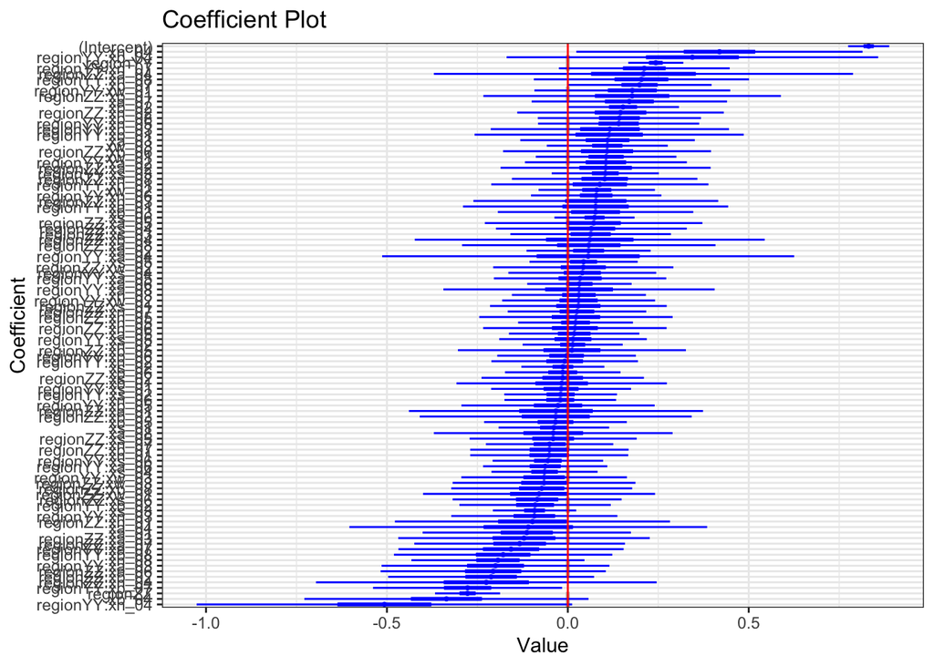

```r
mod4 %>%
  coefplot(scales = "free", sort = "magnitude", pointSize = 1, innerCI = 0.5)+
  geom_vline(xintercept = 0, color = "red")+
  theme_bw()+
  theme(legend.position = 'none')
```

```r
sig_input_inspect(mod4) %>% head()
```

```
## # A tibble: 5 × 7
##    Value Coefficient    HighInner LowInner HighOuter LowOuter Model
##    <dbl> <fct>              <dbl>    <dbl>     <dbl>    <dbl> <chr>
## 1 -0.277 regionZZ          -0.232   -0.322   -0.187   -0.367  model
## 2 -0.277 regionYY:xb_07    -0.146   -0.408   -0.0158  -0.538  model
## 3  0.243 regionYY           0.281    0.205    0.319    0.167  model
## 4  0.419 xn_04              0.617    0.221    0.815    0.0236 model
## 5  0.832 (Intercept)        0.860    0.803    0.888    0.775  model
```

regionZZ, regionYY interact with xb_07 region YY, etc. xn_04 are important features

# 7 Model Export

```r
mod9 %>% readr::write_rds('models/lm_mod9.rds')
mod3 %>% readr::write_rds('models/lm_mod9.rds')
mod4 %>% readr::write_rds('models/lm_mod4.rds')
```